# M3 2017 Workshop Code

Zachary Fisher

May 25, 2017

# Exercise 1: MIIV Search

### Load MIIVsem

```r
library(MIIVsem)
```

### Rename data to match slides

```r
data <- bollen1989a
colnames(data) <- c(paste0("Z",4:11), paste0("Z",1:3))
```

### Specify industrialization-democracy model

```r
model.indem1 <- '
  L1 =~ Z1 + Z2 + Z3
  L2 =~ Z4 + Z5 + Z6  + Z7
  L3 =~ Z8 + Z9 + Z10 + Z11
  L2  ~ L1
  L3  ~ L1 + L2
  Z4 ~~ Z8
  Z5 ~~ Z7 + Z9
  Z6 ~~ Z10
  Z7 ~~ Z11
  Z9 ~~ Z11
'
```

### Run MIIV search

```r
miivs(model.indem1)
```

```
## Model Equation Information
##
##  LHS RHS    MIIVs
##  Z2  Z1     Z4, Z5, Z6, Z7, Z9, Z3, Z8, Z10, Z11
##  Z3  Z1     Z4, Z5, Z6, Z7, Z9, Z2, Z8, Z10, Z11
##  Z5  Z4     Z6, Z1, Z2, Z3, Z10, Z11
##  Z6  Z4     Z5, Z7, Z9, Z1, Z2, Z3, Z11
##  Z7  Z4     Z6, Z9, Z1, Z2, Z3, Z10
##  Z9  Z8     Z6, Z7, Z1, Z2, Z3, Z10
##  Z10 Z8     Z5, Z7, Z9, Z1, Z2, Z3, Z11
##  Z11 Z8     Z5, Z6, Z1, Z2, Z3, Z10
##  Z4  Z1     Z2, Z3
##  Z8  Z1, Z4 Z5, Z6, Z7, Z2, Z3
```

# Exercise 2: MIIV Estimation

### Specify industrialization-democracy model

```r
model.indem1 <- '
  L1 =~ Z1 + Z2 + Z3
  L2 =~ Z4 + Z5 + Z6  + Z7
  L3 =~ Z8 + Z9 + Z10 + Z11
  L2  ~ L1
  L3  ~ L1 + L2
  Z4 ~~ Z8
  Z5 ~~ Z7 + Z9
  Z6 ~~ Z10
  Z7 ~~ Z11
  Z9 ~~ Z11
'
```

### Estimate model

```r
miive(model.indem1, data)
```

```
## MIIVsem (0.5.2) results
##
## Number of observations                                                     75
## Number of equations                                                        10
## Estimator                                                           MIIV-2SLS
## Standard Errors                                                      standard
## Missing                                                              listwise
##
##
## Parameter Estimates:
##
##
## STRUCTURAL COEFFICIENTS:
##                    Estimate  Std.Err  z-value  P(>|z|)   Sargan   df   P(Chi)
##   L1 =~
##     Z1                1.000
##     Z2                2.078    0.128   16.171    0.000    8.301    8    0.405
##     Z3                1.751    0.149   11.782    0.000    8.738    8    0.365
##   L2 =~
##     Z4                1.000
##     Z5                1.139    0.179    6.371    0.000    8.409    5    0.135
##     Z6                0.969    0.140    6.924    0.000    5.874    6    0.437
##     Z7                1.210    0.139    8.713    0.000    4.276    5    0.510
##   L3 =~
##     Z8                1.000
##     Z9                1.051    0.165    6.377    0.000    8.712    5    0.121
##     Z10               1.180    0.151    7.814    0.000    9.538    6    0.146
##     Z11               1.203    0.154    7.798    0.000    2.795    5    0.731
##
##   L2 ~
##     L1                1.261    0.426    2.962    0.003    0.503    1    0.478
##   L3 ~
##     L1                1.123    0.312    3.598    0.000    0.801    3    0.849
##     L2                0.724    0.101    7.140    0.000
##
## INTERCEPTS:
##                    Estimate  Std.Err  z-value  P(>|z|)
##     L2               -0.909    2.170   -0.419    0.675
##     L3               -4.499    1.424   -3.160    0.002
##     Z1                0.000
##     Z10               0.135    0.830    0.163    0.870
##     Z11              -2.137    0.853   -2.505    0.012
##     Z2               -5.711    0.654   -8.727    0.000
##     Z3               -5.292    0.758   -6.985    0.000
##     Z4                0.000
##     Z5               -1.969    1.044   -1.886    0.059
##     Z6                1.265    0.814    1.553    0.120
##     Z7               -2.160    0.814   -2.654    0.008
##     Z8                0.000
##     Z9               -2.418    0.909   -2.659    0.008
```

# Exercise 3: Adjusted Sargan Test

### Estimate model with Adjusted Sargan Test

```r
miive(model.indem1, data, sarg.adjust = "holm")
```

```
## MIIVsem (0.5.2) results
##
## Number of observations                                                     75
## Number of equations                                                        10
## Estimator                                                           MIIV-2SLS
## Standard Errors                                                      standard
## Missing                                                              listwise
##
##
## Parameter Estimates:
##
##
## STRUCTURAL COEFFICIENTS:
##                    Estimate  Std.Err  z-value  P(>|z|)   Sargan   df   P(Chi)
##   L1 =~
##     Z1                1.000
##     Z2                2.078    0.128   16.171    0.000    8.301    8    1.000
##     Z3                1.751    0.149   11.782    0.000    8.738    8    1.000
##   L2 =~
##     Z4                1.000
##     Z5                1.139    0.179    6.371    0.000    8.409    5    1.000
##     Z6                0.969    0.140    6.924    0.000    5.874    6    1.000
##     Z7                1.210    0.139    8.713    0.000    4.276    5    1.000
##   L3 =~
##     Z8                1.000
##     Z9                1.051    0.165    6.377    0.000    8.712    5    1.000
##     Z10               1.180    0.151    7.814    0.000    9.538    6    1.000
##     Z11               1.203    0.154    7.798    0.000    2.795    5    1.000
##
##   L2 ~
##     L1                1.261    0.426    2.962    0.003    0.503    1    1.000
##   L3 ~
##     L1                1.123    0.312    3.598    0.000    0.801    3    1.000
##     L2                0.724    0.101    7.140    0.000
##
## INTERCEPTS:
##                    Estimate  Std.Err  z-value  P(>|z|)
##     L2               -0.909    2.170   -0.419    0.675
##     L3               -4.499    1.424   -3.160    0.002
##     Z1                0.000
##     Z10               0.135    0.830    0.163    0.870
##     Z11              -2.137    0.853   -2.505    0.012
##     Z2               -5.711    0.654   -8.727    0.000
##     Z3               -5.292    0.758   -6.985    0.000
##     Z4                0.000
##     Z5               -1.969    1.044   -1.886    0.059
##     Z6                1.265    0.814    1.553    0.120
##     Z7               -2.160    0.814   -2.654    0.008
##     Z8                0.000
##     Z9               -2.418    0.909   -2.659    0.008
```

# Exercise 4: Bootstrap SEs and CIs

### Estimate model with boostrap SEs and CIs

```r
miive(model.indem1, data, se = "boot", boot.ci = "perc")
```

```
## MIIVsem (0.5.2) results
##
## Number of observations                                                     75
## Number of equations                                                        10
## Estimator                                                           MIIV-2SLS
## Standard Errors                                                     bootstrap
## Missing                                                              listwise
##
## Bootstrap reps requested                                                 1000
## Bootstrap reps successful                                                1000
## Bootstrap intervals                                                Percentile
##
##
## Parameter Estimates:
##
##
## STRUCTURAL COEFFICIENTS:
##                    Estimate  Std.Err    Lower    Upper   Sargan   df   P(Chi)
##   L1 =~
##     Z1                1.000
##     Z2                2.078    0.127    1.795    2.302    8.301    8    0.405
##     Z3                1.751    0.136    1.470    2.003    8.738    8    0.365
##   L2 =~
##     Z4                1.000
##     Z5                1.139    0.137    0.853    1.396    8.409    5    0.135
##     Z6                0.969    0.138    0.696    1.233    5.874    6    0.437
##     Z7                1.210    0.122    0.928    1.422    4.276    5    0.510
##   L3 =~
##     Z8                1.000
##     Z9                1.051    0.146    0.754    1.325    8.712    5    0.121
##     Z10               1.180    0.150    0.862    1.483    9.538    6    0.146
##     Z11               1.203    0.152    0.901    1.496    2.795    5    0.731
##
##   L2 ~
##     L1                1.261    0.420    0.360    2.037    0.503    1    0.478
##   L3 ~
##     L1                1.123    0.289    0.600    1.740    0.801    3    0.849
##     L2                0.724    0.096    0.520    0.897
##
## INTERCEPTS:
##                    Estimate  Std.Err    Lower    Upper
##     L2               -0.909    2.089   -4.959    3.553
##     L3               -4.499    1.393   -7.260   -1.796
##     Z1                0.000
##     Z10               0.135    0.941   -1.668    2.162
##     Z11              -2.137    0.850   -3.931   -0.491
##     Z2               -5.711    0.665   -6.793   -4.250
##     Z3               -5.292    0.706   -6.584   -3.849
##     Z4                0.000
##     Z5               -1.969    0.715   -3.300   -0.524
##     Z6                1.265    0.881   -0.408    3.071
##     Z7               -2.160    0.700   -3.453   -0.641
##     Z8                0.000
##     Z9               -2.418    0.780   -3.897   -0.857
```

### Compare SEs for Standard Bootstrap with Different Numbers of Replications

```r
fit.standard  <- miive(model.indem1, data)
fit.boot.250  <- miive(model.indem1, data, se = "boot", bootstrap = 250)
fit.boot.500  <- miive(model.indem1, data, se = "boot", bootstrap = 500)
fit.boot.1000 <- miive(model.indem1, data, se = "boot", bootstrap = 1000)

est.standard  <- estimatesTable(fit.standard)[,c("lhs", "op", "rhs", "se")]
est.boot.250  <- estimatesTable(fit.boot.250)[,c("lhs", "op", "rhs", "se")]
est.boot.500  <- estimatesTable(fit.boot.500)[,c("lhs", "op", "rhs", "se")]
est.boot.1000 <- estimatesTable(fit.boot.1000)[,c("lhs", "op", "rhs", "se")]

list.est <- list(est.standard,est.boot.250,est.boot.500, est.boot.1000)
compare.se <- Reduce(function(...) merge(..., by= c("lhs", "op", "rhs")), list.est)

colnames(compare.se) <- c("", "", "", "standard", "boot.250", "boot.500", "boot.1000")

compare.se
```

```
##                standard   boot.250   boot.500  boot.1000
## 1   L1 =~  Z1 0.0000000 0.00000000 0.00000000 0.00000000
## 2   L1 =~  Z2 0.1284989 0.12742501 0.12872420 0.12544599
## 3   L1 =~  Z3 0.1486077 0.13582058 0.13969630 0.13662159
## 4   L2 =~  Z4 0.0000000 0.00000000 0.00000000 0.00000000
## 5   L2 =~  Z5 0.1788162 0.12915152 0.12949939 0.13767319
## 6   L2 =~  Z6 0.1400277 0.14092036 0.13928320 0.13463938
## 7   L2 =~  Z7 0.1388712 0.11266491 0.11571946 0.11415357
## 8   L2  ~  L1 0.4257016 0.39768140 0.41010368 0.40266307
## 9   L2 ~1     2.1695621 1.97418893 2.05307076 2.00564561
## 10  L3 =~ Z10 0.1510235 0.14128360 0.15573979 0.15131801
## 11  L3 =~ Z11 0.1542894 0.13990140 0.15033205 0.15490525
## 12  L3 =~  Z8 0.0000000 0.00000000 0.00000000 0.00000000
## 13  L3 =~  Z9 0.1647411 0.14557995 0.13925430 0.13865454
## 14  L3  ~  L1 0.3121788 0.28802751 0.28480819 0.30286962
## 15  L3  ~  L2 0.1014416 0.09811474 0.09401227 0.09625105
## 16  L3 ~1     1.4238274 1.37756216 1.34587940 1.43924863
## 17  Z1 ~1     0.0000000 0.00000000 0.00000000 0.00000000
## 18 Z10 ~1     0.8295001 0.86510405 0.98007084 0.95569988
## 19 Z11 ~1     0.8529658 0.79319639 0.87094142 0.87840056
## 20  Z2 ~1     0.6543824 0.65755923 0.67032050 0.65318852
## 21  Z3 ~1     0.7575664 0.71062800 0.73270265 0.71014839
## 22  Z4 ~1     0.0000000 0.00000000 0.00000000 0.00000000
## 23  Z5 ~1     1.0439776 0.66484430 0.66810818 0.71867840
## 24  Z6 ~1     0.8144095 0.88147024 0.86191972 0.84884553
## 25  Z7 ~1     0.8137226 0.67665288 0.65471449 0.68032068
## 26  Z8 ~1     0.0000000 0.00000000 0.00000000 0.00000000
## 27  Z9 ~1     0.9094858 0.75788005 0.76058913 0.72419096
```

## Exercise 5: Measurement Model Robustness to Latent Variable Model Misspecification

### Load lavaan

```r
library(lavaan)
```

### Correct and Misspecified Model

- Latent variable model is correct (solid and dashed lines)
- Latent variable model is incorrect (omitting dashed lines)

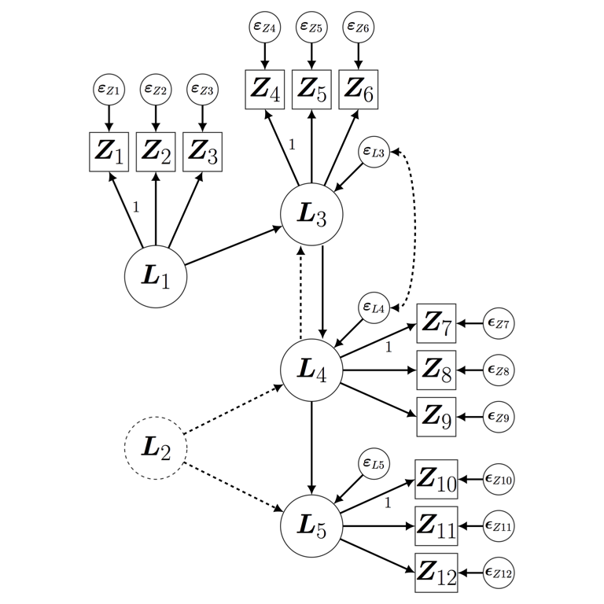

### Specify Data Generating Model

```r
model.sim.1 <- '

  L1  =~ 1*Z1  + 1*Z2  + 1*Z3
  L2  =~ 1*Z13 + 1*Z14 + 1*Z15
  L3  =~ 1*Z4  + 1*Z5  + 1*Z6
  L4  =~ 1*Z7  + 1*Z8  + 1*Z9
  L5  =~ 1*Z10 + 1*Z11 + 1*Z12

  L3 ~  .3*L1 + .5*L4
  L4 ~  .5*L2 + .8*L3
  L5 ~  .3*L2 + .5*L4

  L3 ~~ .6*L4
'
```

### Simulate data

- Simulated data to true model
- 1,000 observations

```r
data.sim.1 <- simulateData(model = model.sim.1,
                           sample.nobs = 1000,
                           seed = 123)
```

### Specify estimating models

```r
model.correct.1 <- '

  L1  =~ Z1  + Z2  + Z3
  L2  =~ Z13 + Z14 + Z15
  L3  =~ Z4  + Z5  + Z6
  L4  =~ Z7  + Z8  + Z9
  L5  =~ Z10 + Z11 + Z12

  L3 ~  L1 + L4
  L4 ~  L2 + L3
  L5 ~  L2 + L4

  L3 ~~ L4

'

model.misspecified.1 <- '
  L1  =~ Z1  + Z2  + Z3
  L2  =~ Z13 + Z14 + Z15
  L3  =~ Z4  + Z5  + Z6
  L4  =~ Z7  + Z8  + Z9
  L5  =~ Z10 + Z11 + Z12

  L3 ~  L1
  L4 ~  L3
  L5 ~  L4
'
```

### Compare Estimates from Estimating Models

```r
  fit.cor.1 <- miive(model.correct.1, data.sim.1)
  fit.mis.1 <- miive(model.misspecified.1, data.sim.1)

  est.cor.1 <- estimatesTable(fit.cor.1)
  est.mis.1 <- estimatesTable(fit.mis.1)

  compare.1 <- merge(
    est.cor.1[est.cor.1$op == "=~", c("lhs","op","rhs","est")],
    est.mis.1[est.mis.1$op == "=~", c("lhs","op","rhs","est")],
    by = c("lhs","op","rhs")
  )
  colnames(compare.1) <- c("","","","est.cor.1","est.mis.1")

  compare.1
```

```
##              est.cor.1 est.mis.1
## 1  L1 =~  Z1 1.0000000 1.0000000
## 2  L1 =~  Z2 1.0873919 1.0873919
## 3  L1 =~  Z3 1.0302098 1.0302098
## 4  L2 =~ Z13 1.0000000 1.0000000
## 5  L2 =~ Z14 1.0076301 1.0076301
## 6  L2 =~ Z15 0.9691372 0.9691372
## 7  L3 =~  Z4 1.0000000 1.0000000
## 8  L3 =~  Z5 0.9933688 0.9933688
## 9  L3 =~  Z6 0.9791256 0.9791256
## 10 L4 =~  Z7 1.0000000 1.0000000
## 11 L4 =~  Z8 1.0159817 1.0159817
## 12 L4 =~  Z9 1.0228551 1.0228551
## 13 L5 =~ Z10 1.0000000 1.0000000
## 14 L5 =~ Z11 1.0019276 1.0019276
## 15 L5 =~ Z12 0.9667204 0.9667204
```

# Exercise 6: Latent Variable Robustness to Measurement Model Misspecification

### Correct and Misspecified Model

- Measurement model is correct (solid and dashed lines)
- Measurement model is incorrect (omitting dashed lines)

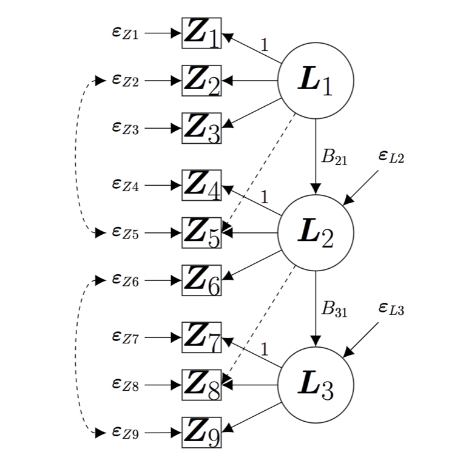

### Specify Data Generating Model

```r
model.sim.2 <- '

  L1  =~ 1*Z1  + 1*Z2  + 1*Z3 + 1*Z5
  L2  =~ 1*Z4  + 1*Z5  + 1*Z6 + 1*Z8
  L3  =~ 1*Z7  + 1*Z8  + 1*Z9

  L2  ~  1*L1
  L3  ~  1*L2

  Z2 ~~ .3*Z5
  Z6 ~~ .3*Z9
'
```

### Simulate data

- Simulated data to true model
- 1,000 observations

```r
data.sim.2 <- simulateData(model = model.sim.2,
                           sample.nobs = 1000,
                           seed = 123)
```

### Specify estimating models

```r
model.correct.2 <- '

  L1  =~ Z1  + Z2  + Z3 + Z5
  L2  =~ Z4  + Z5  + Z6 + Z8
  L3  =~ Z7  + Z8  + Z9

  L2  ~  L1
  L3  ~  L2

  Z2 ~~ Z5
  Z6 ~~ Z9
'

model.misspecified.2 <- '

  L1  =~ Z1  + Z2  + Z3
  L2  =~ Z4  + Z5  + Z6
  L3  =~ Z7  + Z8  + Z9

  L2 ~  L1
  L3 ~  L2
'
```

### Correctly Specified Model (Unadjusted Sargan)

```r
miive(model.correct.2, data.sim.2)
```

```
## MIIVsem (0.5.2) results
##
## Number of observations                                                   1000
## Number of equations                                                         8
## Estimator                                                           MIIV-2SLS
## Standard Errors                                                      standard
## Missing                                                              listwise
##
##
## Parameter Estimates:
##
##
## STRUCTURAL COEFFICIENTS:
##                    Estimate  Std.Err  z-value  P(>|z|)   Sargan   df   P(Chi)
##   L1 =~
##     Z1                1.000
##     Z2                0.927    0.046   20.026    0.000   13.909    5    0.016
##     Z3                0.928    0.044   20.871    0.000    4.656    6    0.589
##     Z5                0.766    0.120    6.402    0.000    3.959    3    0.266
##   L2 =~
##     Z4                1.000
##     Z5                1.117    0.084   13.339    0.000    3.959    3    0.266
##     Z6                0.969    0.034   28.863    0.000    9.882    5    0.079
##     Z8                0.892    0.092    9.660    0.000    5.790    4    0.215
##   L3 =~
##     Z7                1.000
##     Z8                1.125    0.083   13.533    0.000    5.790    4    0.215
##     Z9                1.028    0.031   33.274    0.000    6.722    5    0.242
##
##   L2 ~
##     L1                0.933    0.055   16.861    0.000    0.059    1    0.808
##   L3 ~
##     L2                0.922    0.041   22.242    0.000    8.924    4    0.063
##
## INTERCEPTS:
##                    Estimate  Std.Err  z-value  P(>|z|)
##     L2                0.023    0.051    0.449    0.653
##     L3               -0.013    0.054   -0.236    0.814
##     Z1                0.000
##     Z2               -0.051    0.042   -1.194    0.232
##     Z3               -0.049    0.043   -1.152    0.249
##     Z4                0.000
##     Z5               -0.108    0.052   -2.082    0.037
##     Z6               -0.019    0.045   -0.437    0.662
##     Z7                0.000
##     Z8               -0.056    0.055   -1.007    0.314
##     Z9               -0.008    0.046   -0.183    0.855
```

### Correctly Specified Model (Adjusted Sargan)

```r
miive(model.correct.2, data.sim.2, sarg.adjust = "holm")
```

```
## MIIVsem (0.5.2) results
##
## Number of observations                                                   1000
## Number of equations                                                         8
## Estimator                                                           MIIV-2SLS
## Standard Errors                                                      standard
## Missing                                                              listwise
##
##
## Parameter Estimates:
##
##
## STRUCTURAL COEFFICIENTS:
##                    Estimate  Std.Err  z-value  P(>|z|)   Sargan   df   P(Chi)
##   L1 =~
##     Z1                1.000
##     Z2                0.927    0.046   20.026    0.000   13.909    5    0.130
##     Z3                0.928    0.044   20.871    0.000    4.656    6    1.000
##     Z5                0.766    0.120    6.402    0.000    3.959    3    1.000
##   L2 =~
##     Z4                1.000
##     Z5                1.117    0.084   13.339    0.000    3.959    3    1.000
##     Z6                0.969    0.034   28.863    0.000    9.882    5    0.472
##     Z8                0.892    0.092    9.660    0.000    5.790    4    1.000
##   L3 =~
##     Z7                1.000
##     Z8                1.125    0.083   13.533    0.000    5.790    4    1.000
##     Z9                1.028    0.031   33.274    0.000    6.722    5    1.000
##
##   L2 ~
##     L1                0.933    0.055   16.861    0.000    0.059    1    1.000
##   L3 ~
##     L2                0.922    0.041   22.242    0.000    8.924    4    0.441
##
## INTERCEPTS:
##                    Estimate  Std.Err  z-value  P(>|z|)
##     L2                0.023    0.051    0.449    0.653
##     L3               -0.013    0.054   -0.236    0.814
##     Z1                0.000
##     Z2               -0.051    0.042   -1.194    0.232
##     Z3               -0.049    0.043   -1.152    0.249
##     Z4                0.000
##     Z5               -0.108    0.052   -2.082    0.037
##     Z6               -0.019    0.045   -0.437    0.662
##     Z7                0.000
##     Z8               -0.056    0.055   -1.007    0.314
##     Z9               -0.008    0.046   -0.183    0.855
```

### Misspecified Model (Unadjusted Sargan)

```r
miive(model.misspecified.2, data.sim.2)
```

```
## MIIVsem (0.5.2) results
##
## Number of observations                                                   1000
## Number of equations                                                         8
## Estimator                                                           MIIV-2SLS
## Standard Errors                                                      standard
## Missing                                                              listwise
##
##
## Parameter Estimates:
##
##
## STRUCTURAL COEFFICIENTS:
##                    Estimate  Std.Err  z-value  P(>|z|)   Sargan   df   P(Chi)
##   L1 =~
##     Z1                1.000
##     Z2                0.981    0.044   22.149    0.000   22.579    6    0.001
##     Z3                0.928    0.044   20.871    0.000    4.656    6    0.589
##   L2 =~
##     Z4                1.000
##     Z5                1.602    0.047   33.958    0.000  104.349    6    0.000
##     Z6                0.973    0.034   28.952    0.000   35.800    6    0.000
##   L3 =~
##     Z7                1.000
##     Z8                1.849    0.050   37.256    0.000   64.561    6    0.000
##     Z9                1.026    0.031   33.240    0.000   44.087    6    0.000
##
##   L2 ~
##     L1                0.933    0.055   16.861    0.000    0.059    1    0.808
##   L3 ~
##     L2                0.922    0.041   22.242    0.000    8.924    4    0.063
##
## INTERCEPTS:
##                    Estimate  Std.Err  z-value  P(>|z|)
##     L2                0.023    0.051    0.449    0.653
##     L3               -0.013    0.054   -0.236    0.814
##     Z1                0.000
##     Z2               -0.050    0.044   -1.153    0.249
##     Z3               -0.049    0.043   -1.152    0.249
##     Z4                0.000
##     Z5               -0.122    0.061   -1.987    0.047
##     Z6               -0.020    0.045   -0.438    0.662
##     Z7                0.000
##     Z8               -0.043    0.072   -0.588    0.556
##     Z9               -0.008    0.046   -0.183    0.855
```

### Misspecified Model (Adjusted Sargan)

```r
miive(model.misspecified.2, data.sim.2, sarg.adjust = "holm")
```

```
## MIIVsem (0.5.2) results
##
## Number of observations                                                   1000
## Number of equations                                                         8
## Estimator                                                           MIIV-2SLS
## Standard Errors                                                      standard
## Missing                                                              listwise
##
##
## Parameter Estimates:
##
##
## STRUCTURAL COEFFICIENTS:
##                    Estimate  Std.Err  z-value  P(>|z|)   Sargan   df   P(Chi)
##   L1 =~
##     Z1                1.000
##     Z2                0.981    0.044   22.149    0.000   22.579    6    0.004
##     Z3                0.928    0.044   20.871    0.000    4.656    6    1.000
##   L2 =~
##     Z4                1.000
##     Z5                1.602    0.047   33.958    0.000  104.349    6    0.000
##     Z6                0.973    0.034   28.952    0.000   35.800    6    0.000
##   L3 =~
##     Z7                1.000
##     Z8                1.849    0.050   37.256    0.000   64.561    6    0.000
##     Z9                1.026    0.031   33.240    0.000   44.087    6    0.000
##
##   L2 ~
##     L1                0.933    0.055   16.861    0.000    0.059    1    1.000
##   L3 ~
##     L2                0.922    0.041   22.242    0.000    8.924    4    0.189
##
## INTERCEPTS:
##                    Estimate  Std.Err  z-value  P(>|z|)
##     L2                0.023    0.051    0.449    0.653
##     L3               -0.013    0.054   -0.236    0.814
##     Z1                0.000
##     Z2               -0.050    0.044   -1.153    0.249
##     Z3               -0.049    0.043   -1.152    0.249
##     Z4                0.000
##     Z5               -0.122    0.061   -1.987    0.047
##     Z6               -0.020    0.045   -0.438    0.662
##     Z7                0.000
##     Z8               -0.043    0.072   -0.588    0.556
##     Z9               -0.008    0.046   -0.183    0.855
```

### Compare Regression Estimates from Estimating Models

```r
  fit.cor.2 <- miive(model.correct.2, data.sim.2)
  fit.mis.2 <- miive(model.misspecified.2, data.sim.2)

  est.cor.2 <- estimatesTable(fit.cor.2)
  est.mis.2 <- estimatesTable(fit.mis.2)

  compare.2 <- merge(
    est.cor.2[est.cor.2$op == "~", c("lhs","op","rhs","est")],
    est.mis.2[est.mis.2$op == "~", c("lhs","op","rhs","est")],
    by = c("lhs","op","rhs")
  )

  colnames(compare.2) <- c("","","","est.cor.2","est.mis.2")

  compare.2
```

```
##           est.cor.2 est.mis.2
## 1 L2 ~ L1 0.9332420 0.9332420
## 2 L3 ~ L2 0.9222349 0.9222349
```

# Exercise 6: Latent Variable Robustness to Measurement Model Misspecification 2

### Correct and Misspecified Model

- Measurement model is correct (solid and dashed lines)
- Measurement model is incorrect (omitting dashed lines)

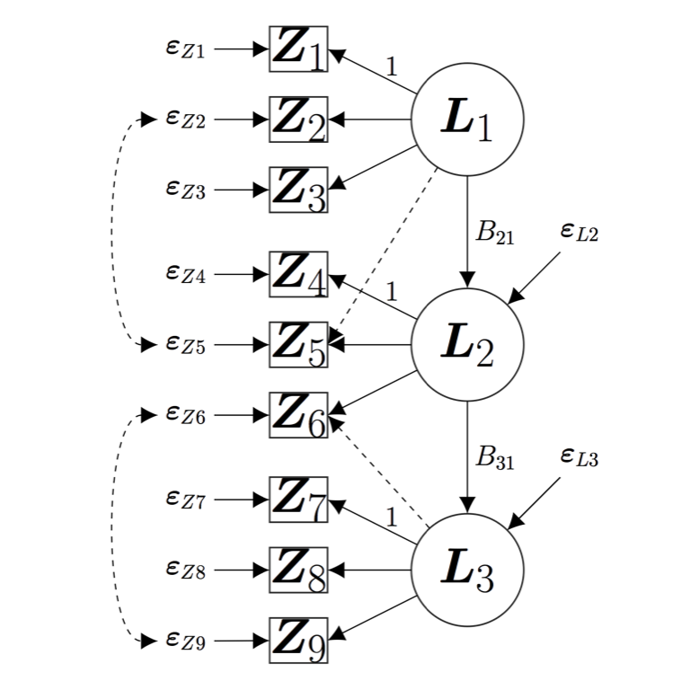

### Specify Data Generating Model

```r
model.sim.3 <- '

  L1  =~ 1*Z1  + 1*Z2  + 1*Z3 + 1*Z5
  L2  =~ 1*Z4  + 1*Z5  + 1*Z6
  L3  =~ 1*Z7  + 1*Z8  + 1*Z9 + 1*Z6

  L2  ~  1*L1
  L3  ~  1*L2

  Z2 ~~ .3*Z5
  Z6 ~~ .3*Z9
'
```

### Simulate data

- Simulated data to true model
- 1,000 observations

```r
data.sim.3 <- simulateData(model = model.sim.3,
                           sample.nobs = 1000,
                           seed = 123)
```

### Specify estimating models

```r
model.correct.3 <- '

  L1  =~ Z1  + Z2  + Z3 + Z5
  L2  =~ Z4  + Z5  + Z6
  L3  =~ Z7  + Z8  + Z9 + Z6

  L2  ~  L1
  L3  ~  L2

  Z2 ~~ Z5
  Z6 ~~ Z9
'

model.misspecified.3 <- '

  L1  =~ Z1  + Z2  + Z3
  L2  =~ Z4  + Z5  + Z6
  L3  =~ Z7  + Z8  + Z9

  L2 ~  L1
  L3 ~  L2
'
```

### Correctly Specified Model

```r
miive(model.correct.3, data.sim.3, sarg.adjust = "holm")
```

```
## MIIVsem (0.5.2) results
##
## Number of observations                                                   1000
## Number of equations                                                         8
## Estimator                                                           MIIV-2SLS
## Standard Errors                                                      standard
## Missing                                                              listwise
##
##
## Parameter Estimates:
##
##
## STRUCTURAL COEFFICIENTS:
##                    Estimate  Std.Err  z-value  P(>|z|)   Sargan   df   P(Chi)
##   L1 =~
##     Z1                1.000
##     Z2                0.954    0.047   20.215    0.000    7.952    5    0.953
##     Z3                0.921    0.044   20.718    0.000    3.205    6    1.000
##     Z5                0.784    0.138    5.673    0.000    3.211    3    1.000
##   L2 =~
##     Z4                1.000
##     Z5                1.094    0.094   11.599    0.000    3.211    3    1.000
##     Z6                0.930    0.091   10.179    0.000    2.893    3    1.000
##   L3 =~
##     Z7                1.000
##     Z6                1.001    0.078   12.757    0.000    2.893    3    1.000
##     Z8                0.960    0.027   35.206    0.000    8.561    6    0.999
##     Z9                0.978    0.029   33.990    0.000   10.685    5    0.464
##
##   L2 ~
##     L1                1.006    0.058   17.382    0.000    0.434    1    1.000
##   L3 ~
##     L2                0.930    0.042   22.001    0.000    7.257    3    0.464
##
## INTERCEPTS:
##                    Estimate  Std.Err  z-value  P(>|z|)
##     L2                0.016    0.053    0.303    0.762
##     L3               -0.033    0.054   -0.617    0.538
##     Z1                0.000
##     Z2               -0.047    0.042   -1.110    0.267
##     Z3               -0.050    0.043   -1.164    0.245
##     Z4                0.000
##     Z5               -0.089    0.053   -1.687    0.092
##     Z6                0.001    0.055    0.024    0.981
##     Z7                0.000
##     Z8                0.045    0.044    1.043    0.297
##     Z9                0.007    0.044    0.167    0.867
```

### Misspecified Model

```r
miive(model.misspecified.3, data.sim.3, sarg.adjust="holm")
```

```
## MIIVsem (0.5.2) results
##
## Number of observations                                                   1000
## Number of equations                                                         8
## Estimator                                                           MIIV-2SLS
## Standard Errors                                                      standard
## Missing                                                              listwise
##
##
## Parameter Estimates:
##
##
## STRUCTURAL COEFFICIENTS:
##                    Estimate  Std.Err  z-value  P(>|z|)   Sargan   df   P(Chi)
##   L1 =~
##     Z1                1.000
##     Z2                1.015    0.045   22.721    0.000   17.476    6    0.031
##     Z3                0.921    0.044   20.718    0.000    3.205    6    1.000
##   L2 =~
##     Z4                1.000
##     Z5                1.613    0.049   32.645    0.000   84.966    6    0.000
##     Z6                2.034    0.061   33.073    0.000  113.670    6    0.000
##   L3 =~
##     Z7                1.000
##     Z8                0.960    0.027   35.206    0.000    8.561    6    0.599
##     Z9                1.012    0.028   36.543    0.000   22.987    6    0.004
##
##   L2 ~
##     L1                1.006    0.058   17.382    0.000    0.434    1    1.000
##   L3 ~
##     L2                1.073    0.042   25.418    0.000  109.497    4    0.000
##
## INTERCEPTS:
##                    Estimate  Std.Err  z-value  P(>|z|)
##     L2                0.016    0.053    0.303    0.762
##     L3               -0.034    0.057   -0.597    0.551
##     Z1                0.000
##     Z2               -0.046    0.043   -1.059    0.290
##     Z3               -0.050    0.043   -1.164    0.245
##     Z4                0.000
##     Z5               -0.101    0.064   -1.577    0.115
##     Z6               -0.033    0.081   -0.402    0.688
##     Z7                0.000
##     Z8                0.045    0.044    1.043    0.297
##     Z9                0.008    0.045    0.186    0.852
```

### Compare Estimates from Estimating Models

```r
  fit.cor.3 <- miive(model.correct.3, data.sim.3)
  fit.mis.3 <- miive(model.misspecified.3, data.sim.3)

  est.cor.3 <- estimatesTable(fit.cor.3)
  est.mis.3 <- estimatesTable(fit.mis.3)

  compare.3 <- merge(
    est.cor.3[est.cor.3$op == "~", c("lhs","op","rhs","est")],
    est.mis.3[est.mis.3$op == "~", c("lhs","op","rhs","est")],
    by = c("lhs","op","rhs")
  )

  colnames(compare.3) <- c("","","","est.cor.3","est.mis.3")

  compare.3
```

```
##           est.cor.3 est.mis.3
## 1 L2 ~ L1 1.0061909  1.006191
## 2 L3 ~ L2 0.9295204  1.072840
```

### Full Output for Misspecified Model

```r
miive(model.misspecified.3, data.sim.3, sarg.adjust = "holm")
```

```
## MIIVsem (0.5.2) results
##
## Number of observations                                                   1000
## Number of equations                                                         8
## Estimator                                                           MIIV-2SLS
## Standard Errors                                                      standard
## Missing                                                              listwise
##
##
## Parameter Estimates:
##
##
## STRUCTURAL COEFFICIENTS:
##                    Estimate  Std.Err  z-value  P(>|z|)   Sargan   df   P(Chi)
##   L1 =~
##     Z1                1.000
##     Z2                1.015    0.045   22.721    0.000   17.476    6    0.031
##     Z3                0.921    0.044   20.718    0.000    3.205    6    1.000
##   L2 =~
##     Z4                1.000
##     Z5                1.613    0.049   32.645    0.000   84.966    6    0.000
##     Z6                2.034    0.061   33.073    0.000  113.670    6    0.000
##   L3 =~
##     Z7                1.000
##     Z8                0.960    0.027   35.206    0.000    8.561    6    0.599
##     Z9                1.012    0.028   36.543    0.000   22.987    6    0.004
##
##   L2 ~
##     L1                1.006    0.058   17.382    0.000    0.434    1    1.000
##   L3 ~
##     L2                1.073    0.042   25.418    0.000  109.497    4    0.000
##
## INTERCEPTS:
##                    Estimate  Std.Err  z-value  P(>|z|)
##     L2                0.016    0.053    0.303    0.762
##     L3               -0.034    0.057   -0.597    0.551
##     Z1                0.000
##     Z2               -0.046    0.043   -1.059    0.290
##     Z3               -0.050    0.043   -1.164    0.245
##     Z4                0.000
##     Z5               -0.101    0.064   -1.577    0.115
##     Z6               -0.033    0.081   -0.402    0.688
##     Z7                0.000
##     Z8                0.045    0.044    1.043    0.297
##     Z9                0.008    0.045    0.186    0.852
```

# Exercise 7: Dimensionality Example

Data comes from a survey conducted in rural clusters of Tanzania (Bollen, 1996). The goal was to collect information on the perceived accessibility of a specific family planning facility that serviced each cluster.

Six informants were chosen: 3 female and 3 male. New informants were chosen for each cluster. Each informant was independently asked to rate the accessibility of the facility. More specifically the women informants were asked to rate how women of childbearing age perceived the accessibility of the clinic and the men informants were asked to rate how accessible men perceived the clinic to be.

The female informants’ ratings are access1-3 and the male informants’ ratings are access4-6.

### Model 1

Using MIIVsem fit a confirmatory factor analysis model with a single accessibility latent variable underlying the six measures. The dataset is packaged with MIIVsem and named `bollen1996`.

The informants change from cluster to cluster. The ordering of the informants is arbitrary, this suggests the factor loadings for the informants might be equal, constrain all the loadings to equality.

Use access1 as the scaling indicator.

To specify equality constraints on parameters in the model syntax use labels prepended to the variable name using the `*` operator. For numeric constrains specify a number instead.

```r
model.1 <- '
  accessibility =~  1*access1 + 1*access2 + 1*access3 +
                    1*access4 + 1*access5 + 1*access6
'
```

MIIVsem also includes an option to estimate test statistics for a large-sample Wald test of linear hypotheses imposed on the MIIV-2SLS coefficient matrix. The $F$ and $\chi^2$ are equivalent asymptotically but their performance may differ in small samples. Assumptions and additional details for each test are given by Greene (2003, pp. 346-347). The conduct the Wald test save the miive object and using the `summary()` method request `restrict.tests=TRUE`.

```r
fit <- miive(model.1, bollen1996, sarg.adjust = "holm")

summary(fit, restrict.tests = TRUE)
```

```
## MIIVsem (0.5.2) results
##
## Number of observations                                                    220
## Number of equations                                                         5
## Estimator                                                           MIIV-2SLS
## Standard Errors                                                      standard
## Missing                                                              listwise
##
##
## Parameter Estimates:
##
##
## STRUCTURAL COEFFICIENTS:
##                    Estimate  Std.Err  z-value  P(>|z|)   Sargan   df   P(Chi)
##   accessibility =~
##     access1           1.000
##     access2           1.000                               3.800    3    0.568
##     access3           1.000                               1.107    3    0.775
##     access4           1.000                              71.309    3    0.000
##     access5           1.000                              82.893    3    0.000
##     access6           1.000                              72.377    3    0.000
##
## INTERCEPTS:
##                    Estimate  Std.Err  z-value  P(>|z|)
##     access1           0.000
##     access2          -0.059    0.075   -0.791    0.429
##     access3          -0.009    0.079   -0.115    0.909
##     access4           0.318    0.102    3.107    0.002
##     access5           0.309    0.101    3.069    0.002
##     access6           0.259    0.105    2.461    0.014
##
##
## MIIV-2SLS LINEAR HYPOTHESIS TESTS:
##
##    access2_access1 = 1
##    access3_access1 = 1
##    access4_access1 = 1
##    access5_access1 = 1
##    access6_access1 = 1
##
##    Wald Test (Chi^2):                          18.1306
##    Degrees of freedom:                               5
##    Pr(>Chi^2) :                                 0.0028
##
##    Wald Test (F):                               3.6261
##    Degrees of freedom:                            5, 5
##    Pr(>F) :                                     0.0029
```

### Model 2

The informants change from cluster to cluster but we have evidence the factor loadings for the female informants are those for the male informants are not equal.

Impose these restrictions and estimate the model. How is the equation level fit now? How does it compare to fit in Model 1?

```r
model.2 <- '
  accessibility =~  1*access1 + 1*access2 + 1*access3 +
                    b*access4 + b*access5 + b*access6
'
```

```r
fit <- miive(model.2, bollen1996, sarg.adjust = "holm")
summary(fit, restrict.tests = TRUE)
```

```
## MIIVsem (0.5.2) results
##
## Number of observations                                                    220
## Number of equations                                                         5
## Estimator                                                           MIIV-2SLS
## Standard Errors                                                      standard
## Missing                                                              listwise
##
##
## Parameter Estimates:
##
##
## STRUCTURAL COEFFICIENTS:
##                    Estimate  Std.Err  z-value  P(>|z|)   Sargan   df   P(Chi)
##   accessibility =~
##     access1           1.000
##     access2           1.000                               3.800    3    0.568
##     access3           1.000                               1.107    3    0.775
##     access4           0.727    0.065   11.249    0.000   82.304    3    0.000
##     access5           0.727    0.065   11.249    0.000   95.313    3    0.000
##     access6           0.727    0.065   11.249    0.000   82.175    3    0.000
##
## INTERCEPTS:
##                    Estimate  Std.Err  z-value  P(>|z|)
##     access1           0.000
##     access2          -0.059    0.075   -0.791    0.429
##     access3          -0.009    0.079   -0.115    0.909
##     access4           1.107    0.209    5.303    0.000
##     access5           1.098    0.208    5.279    0.000
##     access6           1.048    0.210    4.985    0.000
##
##
## MIIV-2SLS LINEAR HYPOTHESIS TESTS:
##
##    access2_access1 = 1
##    access3_access1 = 1
##    access4_access1 - access5_access1 = 0
##    access4_access1 - access6_access1 = 0
##
##    Wald Test (Chi^2):                           0.3103
##    Degrees of freedom:                               4
##    Pr(>Chi^2) :                                 0.9891
##
##    Wald Test (F):                               0.0776
##    Degrees of freedom:                            4, 4
##    Pr(>F) :                                     0.9891
```

### Model 3

If women and men differ in their view of accessibility, then a two factor model could be more appropriate. Create a model that has Female Accessibility as the first factor and Male Accessibility as the second factor. Allow the two factors to correlate.

Scale the Female Accessibility latent variable to access1 and the Male Accessibility latent variable to access4. What happens to the overidentification tests?

```r
model.3 <- '
  femaleAccess =~  access1 + access2 + access3
  maleAccess   =~  access4 + access5 + access6
'
```

```r
fit <- miive(model.3, bollen1996)
summary(fit, restrict.tests = TRUE)
```

```
## MIIVsem (0.5.2) results
##
## Number of observations                                                    220
## Number of equations                                                         4
## Estimator                                                           MIIV-2SLS
## Standard Errors                                                      standard
## Missing                                                              listwise
##
##
## Parameter Estimates:
##
##
## STRUCTURAL COEFFICIENTS:
##                    Estimate  Std.Err  z-value  P(>|z|)   Sargan   df   P(Chi)
##   femaleAccess =~
##     access1           1.000
##     access2           1.041    0.104   10.039    0.000    3.499    3    0.321
##     access3           1.033    0.103   10.034    0.000    0.970    3    0.809
##   maleAccess =~
##     access4           1.000
##     access5           1.026    0.073   14.039    0.000    6.623    3    0.085
##     access6           1.005    0.076   13.285    0.000    2.581    3    0.461
##
## INTERCEPTS:
##                    Estimate  Std.Err  z-value  P(>|z|)
##     access1           0.000
##     access2          -0.177    0.310   -0.572    0.567
##     access3          -0.106    0.309   -0.342    0.732
##     access4           0.000
##     access5          -0.092    0.245   -0.378    0.705
##     access6          -0.075    0.255   -0.295    0.768
```

### Exercise 8: Polychoric Instrumental Variable Estimator

Following the convention used in lavaan, we use the ordered argument to indicate which variables in the model syntax are categorical. This will be demonstrated in the following example.

In our previous Accessibility example, responses were recorded on a 1-5 scale. We will reestimate our final two-factor model to demonstrate the PIV estimator.

```r
model.piv <- '
  femaleAccess =~  access1 + access2 + access3
  maleAccess   =~  access4 + access5 + access6
'
```

```r
miive(model.piv, bollen1996, ordered = paste0("access",1:6))
```

```
## MIIVsem (0.5.2) results
##
## Number of observations                                                    220
## Number of equations                                                         4
## Estimator                                                     MIIV-2SLS (PIV)
## Standard Errors                                                      standard
## Missing                                                              listwise
##
##
## Parameter Estimates:
##
##
## STRUCTURAL COEFFICIENTS:
##                    Estimate  Std.Err  z-value  P(>|z|)   Sargan   df   P(Chi)
##   femaleAccess =~
##     access1           1.000
##     access2           1.039    0.064   16.322    0.000
##     access3           0.983    0.047   20.702    0.000
##   maleAccess =~
##     access4           1.000
##     access5           1.026    0.048   21.306    0.000
##     access6           0.967    0.041   23.515    0.000
```